# Mini Proyecto TD 2024

## 7) ¿Qué tipo de IVA recauda más dinero?

```r
dfIVA <- function(listaArchivos) {
    dfl <- list()   #lista vacía donde se almacenarán los dataframes resultantes

    for (archivo in listaArchivos) {
        texto <- (readLines(archivo, encoding = "windows-1252"))#Extraigo la
        # informacion de los txt
        total1 <- texto[grep("^TOTAL \\(", texto)]
        indice1 <- grep("^IVA BASE", texto)
        indice2 <- grep("^TOTAL \\d", texto)#Obtengo las lineas que contienen el IVA
        IVA <- texto[(indice1 + 1):(indice2 - 1)]
        IVA<- c(IVA,texto[indice2])#Creo un vector con la informacion
        matrizIVA <- matrix(IVA, ncol = 5, byrow = TRUE)#Lo paso a matriz y le
        # doy la forma adecuada para obtener el df que quiero

        dfIVA <- as.data.frame(matrizIVA)

        dfl[[archivo]] <- dfIVA#Almaceno el df en la lista
    }

    df_final<-bind_rows(dfl)#Uno todos los df en uno
    df1 <- df_final %>%#Los datos no estan ordenados por columnas,
      # creo nuevas columnas con la condicion de que cada una sea un tipo
      # de IVA o el total
  rowwise() %>%
  mutate(veintiuno = ifelse(any(startsWith(c_across(everything()), "21")),
                   first(c_across(everything())[startsWith(c_across(everything()),
                                                           "21")]),
                   NA))%>%
    mutate(diez = ifelse(any(startsWith(c_across(everything()), "10")),
                   first(c_across(everything())[startsWith(c_across(everything()),
                                                           "10")]),
                   NA))%>%
  mutate(cinco = ifelse(any(startsWith(c_across(everything()), "5")),
                   first(c_across(everything())[startsWith(c_across(everything()),
                                                           "5")]),
                   NA))%>%
  mutate(cero = ifelse(any(startsWith(c_across(everything()), "0")),
                   first(c_across(everything())[startsWith(c_across(everything()),
                                                           "0")]),
                   NA))%>%
  mutate(total = ifelse(any(startsWith(c_across(everything()), "TOTAL")),
                   first(c_across(everything())[startsWith(c_across(everything()),
                                                           "TOTAL")]),
                   NA))

  #Me quedo con las columnas nuevas y selecciono solo los caracteres que
    #me interesan
  df <-df1%>%
  select(veintiuno,diez,cinco,cero,total)%>%
  mutate(base21=substr(veintiuno,5,8))%>%
  mutate(base10=substr(diez,5,8))%>%
  mutate(base5=substr(cinco,4,8))%>%
  mutate(base0=substr(cero,4,8))%>%
  mutate(totalBase=substr(total,6,(nchar(total)-4)))%>%
  mutate(imponible21=substr(veintiuno,(nchar(veintiuno)-4),
                            nchar(veintiuno)))%>%
  mutate(imponible10=substr(diez,(nchar(diez)-4),nchar(diez)))%>%
  mutate(imponible5=substr(cinco,(nchar(cinco)-4),nchar(cinco)))%>%
  mutate(imponible0=substr(cero,(nchar(cero)-4),nchar(cero)))%>%
  mutate(totalImponible=substr(total,(nchar(total)-4),nchar(total)))%>%
      select(base21,base10,base5,base0,imponible21,imponible10,imponible5,
             imponible0,totalBase,totalImponible) %>%
  mutate_all(~ str_replace_all(., ",", "."))%>%#Reenplazo comas por puntos
    # y paso a numerico
   mutate_all(as.numeric)

    return(df)
}
carpeta <- "data"
fichero<-list.files(path = carpeta, full.names = TRUE, recursive = TRUE,
                    pattern = ".txt")

a<-dfIVA(fichero)
```

En la siguiente gráfica se puede observar el precio total al que se le aplica cada tipo de IVA, es decir, de los 1598.87 euros, que es la suma del precio de todos los tickets, se puede ver como principalmente se aplica el IVA reducido (10%).

```
## [1] 1598.87
```

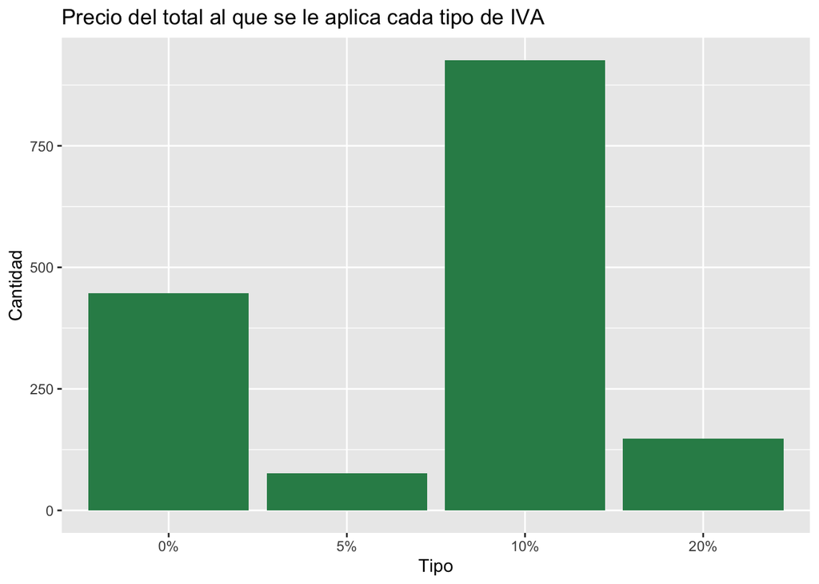

Para continuar, en esta gráfica se puede observar el total imponible de cada tipo de IVA, es decir, de todo el dinero gastado 127.56 euros se han cobrado por el IVA y la mayoría de dinero se ha recaudado por el IVA reducido (10%).

```
## [1] 127.56
```

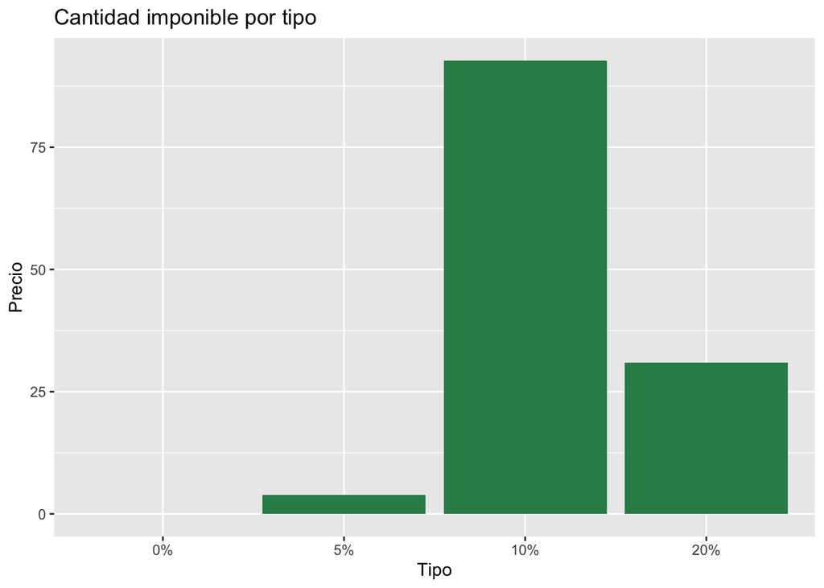

Para terminar, la siguiente gráfica muestra la media de cada tipo de IVA tanto el total, como la parte imponible.

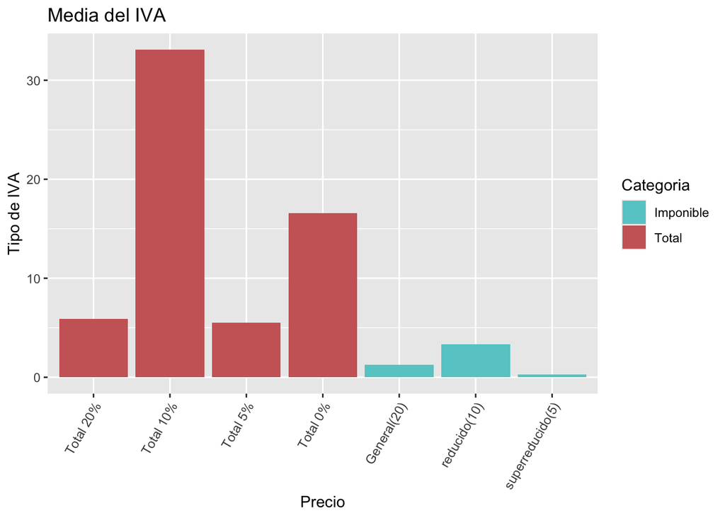